# The Kaplan-Meier Estimatior in R

Md. Ahsanul Islam

2022-06-21

The Kaplan–Meier estimator, often known as the product limit estimator, is a non-parametric statistic used to estimate the survival function using lifetime data. In this post, we will see how to estimate the survival function in this method using R.

# Packages & Data

For fitting a Kaplan-Meier curve, the `survival` package is required -

```r
library(survival)
```

For this example, I will use the addicts dataset -

```r
remotes::install_github("lbraglia/suanselete3")
data(addicts, package = 'suanselete3')
```

Here, the package `suanselete3` is an unofficial companion to the textbook “Survival Analysis - A Self-Learning Text” by D.G. Kleinbaum and M. Klein (3rd Ed., 2012) including all the accompanying datasets. I have loaded the addicts data set from this package.

Description of the data (event=dropped out) - 1. ID – Patient ID  
2. CLINIC – Indicates which methadone treatment clinic the patient attended (coded 1 or 2)  
3. STATUS – Indicates whether the patient dropped out of the clinic (coded 1) or was censored (coded 0)  
4. SURVT – The time (in days) until the patient dropped out of the clinic or was censored  
5. PRISON – Indicates whether the patient had a prison record (coded 1) or not (coded 0)  
6. DOSE – A continuous variable for the patient’s maximum methadone dose (mg/day)

# Data Preparation

Let’s have an idea about the data set -

```r
head(addicts)
```

```
#   id clinic status survt prison dose
# 1  1      1      1   428      0   50
# 2  2      1      1   275      1   55
# 3  3      1      1   262      0   55
# 4  4      1      1   183      0   30
# 5  5      1      1   259      1   65
# 6  6      1      1   714      0   55
```

Check the class of the data set imported in R -

```r
class(addicts)
```

```
# [1] "data.frame"
```

It is a data frame. To work with this, firstly, we need to create a `Surv` object which will be used as a response variable -

```r
Y <- Surv(time = addicts$survt, event = addicts$status == 1)
Y
```

```
#   [1]  428   275   262   183   259   714   438   796+  892   393   161+  836
#  [13]  523   612   212   399   771   514   512   624   209   341   299   826+
#  [25]  262   566+  368   302   602+  652   293   564+  394   755   591   787+
#  [37]  739   550   837   612   581+  523   504   785   774   560   160   482
#  [49]  518   683   147   563   646   899   857   180   452   760   496   258
#  [61]  181   386   439+  563+  337   613+  192   405+  667   905+  247   821
#  [73]  821   517+  346+  294   244    95   376   212    96   532   522   679
#  [85]  408+  840+  148+  168   489   541+  205   475+  237   517   749   150
#  [97]  465   708   713+  146+  450   555+  460    53+  122    35   532+  684+
# [109]  769+  591+  769+  609+  932+  932+  587+   26    72+  641+  367+  633+
# [121]  661   232    13   563+  969+ 1052+  944+  881+  190    79   884+  170
# [133]  286   358+  326+  769+  161   564+  268   611+  322  1076+    2+  788+
# [145]  575+  109   730+  790+  456+  231   143    86+ 1021+  684+  878   216
# [157]  808+  268   222+  683+  496+  389   126    17   350   531+  317+  461+
# [169]   37   167   358    49   457   127     7    29    62   150+  223   129+
# [181]  204+  129   581   176    30    41   543+  210+  193   434   367   348
# [193]   28+  337+  175+  149   546    84   283+  533   207   216    28+   67
# [205]   62+  111+  257   136   342+   41   531+   98+  145    50    53+  103+
# [217]    2+  157    75    19    35   394+  117   175   180   314   480+  325+
# [229]  280   204   366   531+   59    33   540   551+   90    47
```

Here the time variable `survt` has been assigned with the plus sign (+) indicating censored and not censored otherwise (based on `status` variable).

# Model

In the following code, Y~1 requests an intercept only model -

```r
kmfit1 = survfit(Y~1)
kmfit1
```

```
# Call: survfit(formula = Y ~ 1)
#
#       n  events  median 0.95LCL 0.95UCL
#     238     150     504     399     560
```

The output contains descriptive information on the number of records, the number at risk at time 0, the number of events, and the median estimated survival time with a 95% confidence interval.

The summary function shows the survival estimates -

```r
summary(kmfit1)
```

```
# Call: survfit(formula = Y ~ 1)
#
#  time n.risk n.event survival std.err lower 95% CI upper 95% CI
#     7    236       1    0.996 0.00423       0.9875        1.000
#    13    235       1    0.992 0.00597       0.9799        1.000
#    17    234       1    0.987 0.00729       0.9731        1.000
#    19    233       1    0.983 0.00840       0.9667        1.000
#    26    232       1    0.979 0.00937       0.9606        0.997
#    29    229       1    0.975 0.01026       0.9546        0.995
#    30    228       1    0.970 0.01107       0.9488        0.992
#    33    227       1    0.966 0.01182       0.9431        0.989
#    35    226       2    0.957 0.01317       0.9320        0.984
#    37    224       1    0.953 0.01379       0.9265        0.981
#    41    223       2    0.945 0.01493       0.9158        0.974
#    47    221       1    0.940 0.01546       0.9105        0.971
#    49    220       1    0.936 0.01597       0.9053        0.968
#    50    219       1    0.932 0.01646       0.9001        0.965
#    59    216       1    0.927 0.01694       0.8949        0.961
#    62    215       1    0.923 0.01740       0.8897        0.958
#    67    213       1    0.919 0.01785       0.8845        0.954
#    75    211       1    0.914 0.01829       0.8793        0.951
#    79    210       1    0.910 0.01871       0.8742        0.948
#    84    209       1    0.906 0.01913       0.8691        0.944
#    90    207       1    0.901 0.01953       0.8639        0.940
#    95    206       1    0.897 0.01992       0.8588        0.937
#    96    205       1    0.893 0.02029       0.8537        0.933
#   109    202       1    0.888 0.02067       0.8486        0.930
#   117    200       1    0.884 0.02104       0.8435        0.926
#   122    199       1    0.879 0.02140       0.8384        0.922
#   126    198       1    0.875 0.02174       0.8333        0.919
#   127    197       1    0.870 0.02208       0.8282        0.915
#   129    196       1    0.866 0.02241       0.8232        0.911
#   136    194       1    0.862 0.02274       0.8181        0.907
#   143    193       1    0.857 0.02305       0.8131        0.903
#   145    192       1    0.853 0.02336       0.8080        0.900
#   147    190       1    0.848 0.02366       0.8030        0.896
#   149    188       1    0.844 0.02396       0.7979        0.892
#   150    187       1    0.839 0.02426       0.7929        0.888
#   157    185       1    0.835 0.02455       0.7878        0.884
#   160    184       1    0.830 0.02483       0.7828        0.880
```

[output cut: 88 more lines]

```
#   714     37       1    0.316 0.03623       0.2527        0.396
#   739     35       1    0.307 0.03631       0.2437        0.387
#   749     34       1    0.298 0.03635       0.2348        0.379
#   755     33       1    0.289 0.03635       0.2260        0.370
#   760     32       1    0.280 0.03632       0.2173        0.361
#   771     28       1    0.270 0.03638       0.2075        0.352
#   774     27       1    0.260 0.03638       0.1978        0.342
#   785     26       1    0.250 0.03633       0.1882        0.332
#   821     20       2    0.225 0.03675       0.1635        0.310
#   836     17       1    0.212 0.03690       0.1506        0.298
#   837     16       1    0.199 0.03689       0.1380        0.286
#   857     14       1    0.184 0.03688       0.1246        0.273
#   878     13       1    0.170 0.03667       0.1116        0.260
#   892     10       1    0.153 0.03675       0.0958        0.245
#   899      9       1    0.136 0.03639       0.0807        0.230
```

For specified survival time, the `times` argument can be used. For example, to produce, survival estimate for survival time 30 -

```r
summary(kmfit1, times = 30)
```

```
# Call: survfit(formula = Y ~ 1)
#
#  time n.risk n.event survival std.err lower 95% CI upper 95% CI
#    30    228       7     0.97  0.0111        0.949        0.992
```

To get survival estimates at different survival times, say in interval of 100 -

```r
summary(kmfit1,times=seq(0, max(addicts$survt), by=100))
```

```
# Call: survfit(formula = Y ~ 1)
#
#  time n.risk n.event survival std.err lower 95% CI upper 95% CI
#     0    238       0    1.000  0.0000       1.0000        1.000
#   100    203      25    0.893  0.0203       0.8537        0.933
#   200    168      27    0.771  0.0280       0.7176        0.827
#   300    137      27    0.645  0.0323       0.5844        0.711
#   400    111      17    0.561  0.0339       0.4984        0.631
#   500     92      11    0.503  0.0346       0.4398        0.576
#   600     57      17    0.404  0.0353       0.3404        0.479
#   700     39       9    0.334  0.0361       0.2699        0.412
#   800     21       9    0.250  0.0363       0.1882        0.332
#   900      8       8    0.136  0.0364       0.0807        0.230
#  1000      3       0    0.136  0.0364       0.0807        0.230
```

To plot the output -

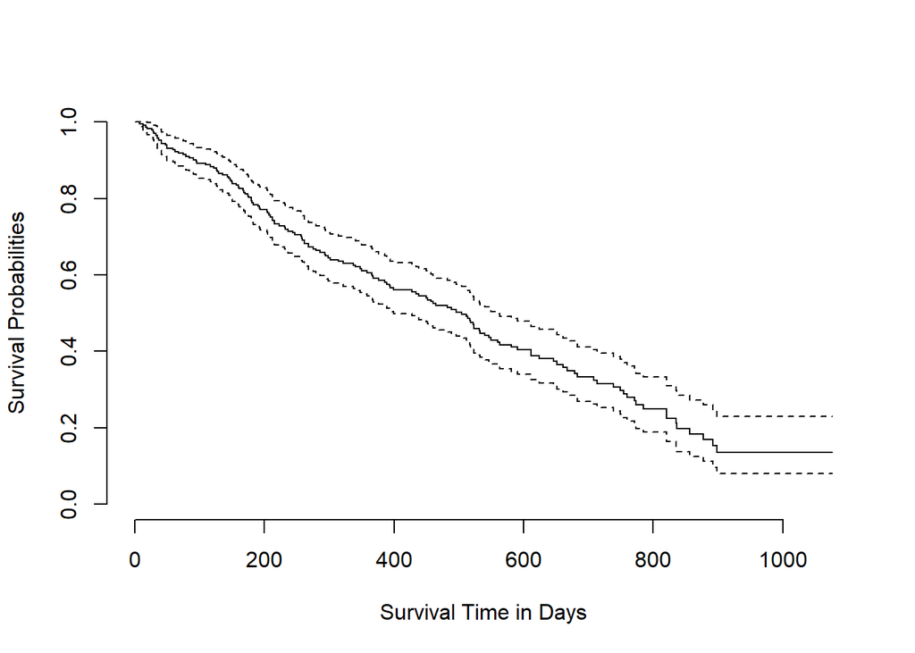

```r
plot(kmfit1, frame.plot=FALSE,
     xlab = "Survival Time in Days",
     ylab = "Survival Probabilities")
```

## Stratify by Other Variable

To stratify the survival experience by CLINIC variable we need to fit a different model including the variable CLINIC instead of 1 -

```r
kmfit2 = survfit(Y ~ clinic, data = addicts)
kmfit2
```

```
# Call: survfit(formula = Y ~ clinic, data = addicts)
#
#            n events median 0.95LCL 0.95UCL
# clinic=1 163    122    428     348     514
# clinic=2  75     28     NA     661      NA
```

Let’s see the survival estimates at a time interval of 100 -

```r
summary(kmfit2,times=seq(0,max(addicts$survt),by=100))
```

```
# Call: survfit(formula = Y ~ clinic, data = addicts)
#
#                 clinic=1
#  time n.risk n.event survival std.err lower 95% CI upper 95% CI
#     0    163       0   1.0000  0.0000      1.00000        1.000
#   100    137      20   0.8746  0.0262      0.82467        0.928
#   200    110      20   0.7420  0.0353      0.67601        0.814
#   300     87      20   0.6046  0.0399      0.53120        0.688
#   400     68      14   0.5025  0.0415      0.42741        0.591
#   500     53       9   0.4319  0.0418      0.35719        0.522
#   600     30      16   0.2951  0.0403      0.22570        0.386
#   700     20       8   0.2113  0.0383      0.14818        0.301
#   800     10       8   0.1268  0.0326      0.07660        0.210
#   900      1       7   0.0181  0.0172      0.00283        0.116
#
#                 clinic=2
#  time n.risk n.event survival std.err lower 95% CI upper 95% CI
#     0     75       0    1.000  0.0000        1.000        1.000
#   100     66       5    0.932  0.0294        0.876        0.991
#   200     58       7    0.832  0.0442        0.750        0.924
#   300     50       7    0.730  0.0530        0.633        0.842
#   400     43       3    0.685  0.0558        0.584        0.804
#   500     39       2    0.653  0.0577        0.549        0.776
#   600     27       1    0.634  0.0590        0.528        0.761
#   700     19       1    0.606  0.0625        0.495        0.742
#   800     11       1    0.575  0.0669        0.457        0.722
#   900      7       1    0.517  0.0812        0.380        0.703
#  1000      3       0    0.517  0.0812        0.380        0.703
```

Notice for CLINIC=1, survival times stopped at 900 rather than 1000, because no subject was at risk on day 1000.

We can plot the survival curve for the two clinics -

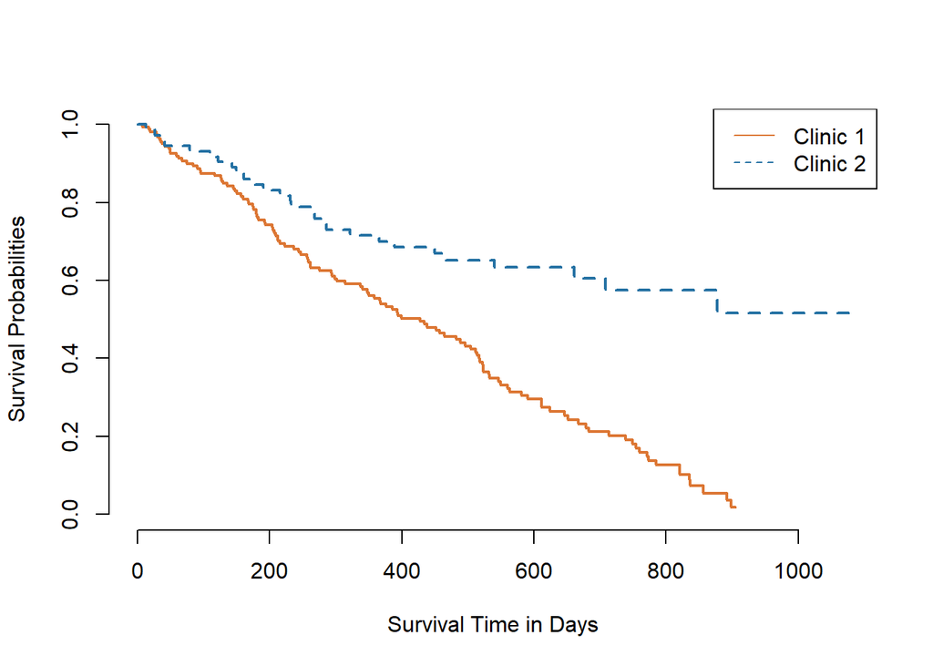

```r
plot(kmfit2, frame.plot=FALSE, lwd = 2,
     lty = c("solid","dashed"),
     col=c("#DC7633","#2471A3"),
     xlab = "Survival Time in Days",
     ylab = "Survival Probabilities")
legend("topright", c("Clinic 1", "Clinic 2"),
       lty = c("solid","dashed"), col=c("#DC7633","#2471A3"))
```

The plot indicates that subjects from CLINIC=2 have a higher rate of survival than subjects from CLINIC=1.

Reference:  
1. Kleinbaum, D. G., & Klein, M. (2012). Survival analysis: a self-learning text (Vol. 3). New York: Springer.